## A. Overview

[output not shown]

## B. Brief Background

[output not shown]

## C. Data Exploration

### i. Dataset:

Full data for this project is available at http://groupware.les.inf.puc-rio.br/har.

**Velloso, E.; Bulling, A.; Gellersen, H.; Ugulino, W.; Fuks, H. “Qualitative Activity Recognition of Weight Lifting Exercises. Proceedings of 4th International Conference in Cooperation with SIGCHI (Augmented Human ’13)”. Stuttgart, Germany: ACM SIGCHI, 2013.**

A special thanks to authors of this data for allowing its usage for this academic assignment

**The training data** **Link**: https://d396qusza40orc.cloudfront.net/predmachlearn/pml-training.csv

**The test data** **Link** : https://d396qusza40orc.cloudfront.net/predmachlearn/pml-testing.csv

### ii. Loading Data

```r
suppressPackageStartupMessages(library(caret))
suppressPackageStartupMessages(library(ggplot2))
suppressPackageStartupMessages(library(corrplot))

url1 <- "https://d396qusza40orc.cloudfront.net/predmachlearn/pml-training.csv"
url2 <- "https://d396qusza40orc.cloudfront.net/predmachlearn/pml-testing.csv"
filename1 <- "pml-training.csv"
filename2 <- "pml-testing.csv"
download.file(url=url1, destfile=filename1,method="curl")
download.file(url=url2, destfile=filename2,method="curl")
training_raw <- read.csv("pml-training.csv", sep = ",", header = TRUE, na.strings = c("", "NA"))
testing_raw <- read.csv("pml-testing.csv", sep = ",", header = TRUE, na.strings =c("","NA"))
```

### iii. Stucture of data

```r
dim(training_raw)
```

```
## [1] 19622   160
```

```r
dim(testing_raw)
```

```
## [1]  20 160
```

### iv. Cleaning of dataset

*On checking variables in dataset, we see that test dataset have variable “problem_id” which is not present in train. lets see it content*

```r
unique(training_raw$classe)
```

```
## [1] A B C D E
## Levels: A B C D E
```

```r
unique(testing_raw$problem_id)
```

```
##  [1]  1  2  3  4  5  6  7  8  9 10 11 12 13 14 15 16 17 18 19 20
```

*Clearly it is different from classe variable in training set. So, we have to remove it as we cannot predict based on new variable not defined in prediction model ( sourced through train dataset)*

```r
testing_raw <- testing_raw[ , -(which(names(testing_raw) == "problem_id"))]
```

Both data-sets have numerous variables i.e 160 variables. to check if we can trim, we will run 2 process. 1. Removing variables with less influence on result owing to very low variability in the measurements. 2. Removing variables with large number of NA variables.

```r
# removing variables with very low variance
nsv <- nearZeroVar(training_raw,saveMetrics=TRUE)
zerovar <- names(training_raw[, nsv$nzv])

training_v1 <- training_raw[,!nsv$nzv]
testing_v1 <- testing_raw[, -which(names(testing_raw) %in% zerovar)]
```

```r
#removing variables with large NAs
na_filter    <- sapply(training_v1, function(x) mean(is.na(x))) > 0.95
training_v2 <- training_v1[, na_filter==FALSE]
testing_v2  <- testing_v1[, which(names(testing_v1) %in% names(training_v2))]
sum(is.na(training_v2))
```

```
## [1] 0
```

*Final values shows there are no more NA in trainingdata set*

*We also observed that 1st 6 variables capture reduntant information from exercise point of view. We will remove them as well*

```r
training_v3 <- training_v2[,-(1:6)]
testing_v3 <- testing_v2[, -(1:6)]
dim(training_v3)
```

```
## [1] 19622    53
```

With the cleaning process above, the number of variables for the analysis has been reduced to 53 only.

## D. Variable relationships

Lets explore correlation among variables before proceeding further

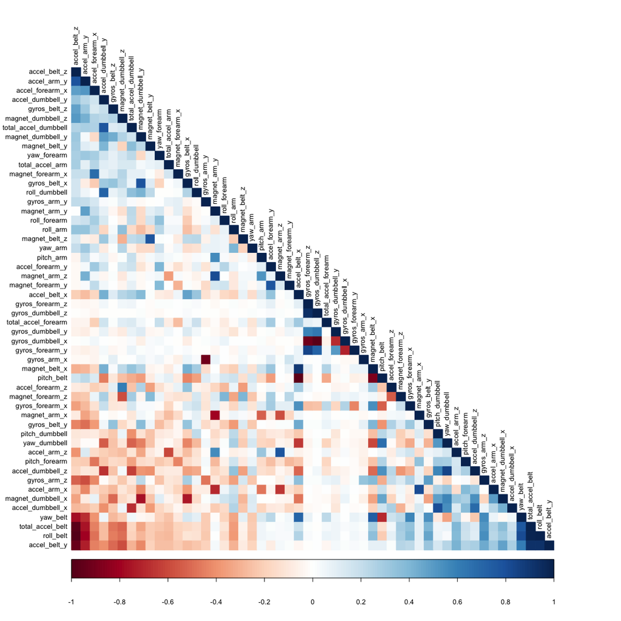

```r
corMatrix <- cor(training_v3[, -ncol(training_v3)])
corrplot(corMatrix, order = "FPC", method = "color", type = "lower", tl.cex = 0.8, tl.col = rgb(0, 0, 0))
```

Since correlations are quite few in nature, we could avoid PCA preprocessing and directly explore modelling

## D. Model Building:

Though random forest method will most probably yield better result, for better confidence in our model we will try to check accuracy for other model methods as well. But first lets split training-set it into 1. training subset 2. validation subset

```r
inTrain <- createDataPartition(y=training_v3$classe, p=0.7, list=FALSE)
training_clean <- training_v3[inTrain,]
validation_clean <- training_v3[-inTrain,]
```

**Method 1**: **Random forest**

```r
set.seed(123)
controlRF <- trainControl(method="cv", number=3, verboseIter=FALSE)
modelRF <- train(classe ~ ., data=training_clean, method="rf",trControl=controlRF, message = FALSE)
validation_pred_RF <- predict(modelRF, newdata = validation_clean)
confusionMatrix(validation_pred_RF,validation_clean$classe)
```

```
## Confusion Matrix and Statistics
##
##           Reference
## Prediction    A    B    C    D    E
##          A 1672    9    0    0    0
##          B    1 1129    2    0    0
##          C    1    1 1020    9    0
##          D    0    0    4  955    3
##          E    0    0    0    0 1079
##
## Overall Statistics
##
##                Accuracy : 0.9949
##                  95% CI : (0.9927, 0.9966)
##     No Information Rate : 0.2845
##     P-Value [Acc > NIR] : < 2.2e-16
##
##                   Kappa : 0.9936
##  Mcnemar's Test P-Value : NA
##
## Statistics by Class:
##
##                      Class: A Class: B Class: C Class: D Class: E
## Sensitivity            0.9988   0.9912   0.9942   0.9907   0.9972
## Specificity            0.9979   0.9994   0.9977   0.9986   1.0000
## Pos Pred Value         0.9946   0.9973   0.9893   0.9927   1.0000
## Neg Pred Value         0.9995   0.9979   0.9988   0.9982   0.9994
## Prevalence             0.2845   0.1935   0.1743   0.1638   0.1839
## Detection Rate         0.2841   0.1918   0.1733   0.1623   0.1833
## Detection Prevalence   0.2856   0.1924   0.1752   0.1635   0.1833
## Balanced Accuracy      0.9983   0.9953   0.9959   0.9946   0.9986
```

**Method 1**: **General boosting method**

```r
controlGBM <- trainControl(method="repeatedcv", number=5, repeats = 1)
modelGBM <- train(classe ~ ., data=training_clean, method="gbm",trControl=controlGBM, verbose = FALSE)
validation_pred_GBM <- predict(modelGBM, newdata = validation_clean)
confusionMatrix(validation_pred_GBM,validation_clean$classe)
```

```
## Confusion Matrix and Statistics
##
##           Reference
## Prediction    A    B    C    D    E
##          A 1642   42    0    1    1
##          B   23 1066   25    1   13
##          C    5   27  991   31    6
##          D    3    1    9  928   17
##          E    1    3    1    3 1045
##
## Overall Statistics
##
##                Accuracy : 0.9638
##                  95% CI : (0.9587, 0.9684)
##     No Information Rate : 0.2845
##     P-Value [Acc > NIR] : < 2.2e-16
##
##                   Kappa : 0.9542
##  Mcnemar's Test P-Value : 4.301e-06
##
## Statistics by Class:
##
##                      Class: A Class: B Class: C Class: D Class: E
## Sensitivity            0.9809   0.9359   0.9659   0.9627   0.9658
## Specificity            0.9896   0.9869   0.9858   0.9939   0.9983
## Pos Pred Value         0.9739   0.9450   0.9349   0.9687   0.9924
## Neg Pred Value         0.9924   0.9847   0.9927   0.9927   0.9923
## Prevalence             0.2845   0.1935   0.1743   0.1638   0.1839
## Detection Rate         0.2790   0.1811   0.1684   0.1577   0.1776
## Detection Prevalence   0.2865   0.1917   0.1801   0.1628   0.1789
## Balanced Accuracy      0.9852   0.9614   0.9758   0.9783   0.9821
```

** Performing check on importance of variables **

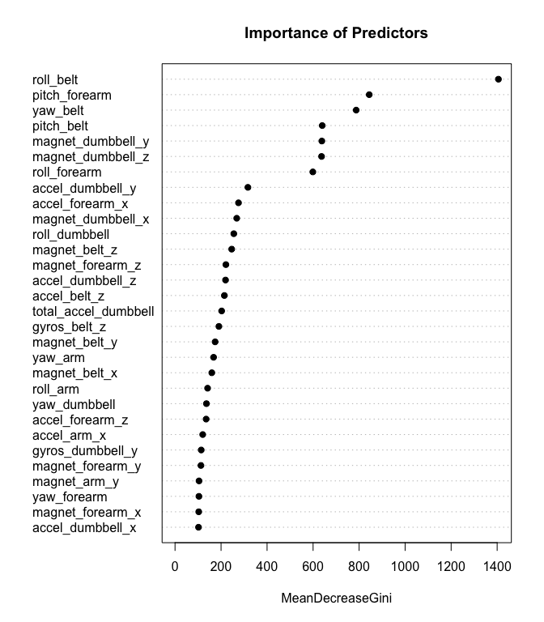

```r
varImpPlot(modelRF$finalModel, sort = TRUE, pch = 19, col = 1, cex = 1, main = "Importance of Predictors")
```

## E. Predicting on test sample :

```r
test_pred<- predict( modelRF, newdata= testing_v3)
test_pred
```

```
##  [1] B A B A A E D B A A B C B A E E A B B B
## Levels: A B C D E
```